# Risk Factor Analysis

## Outcome Variable

**Outcome Variable:** ever_wasted

## Predictor Variables

**Intervention Variable:** meducyrs

**Adjustment Set:**

- arm
- W_mage
- feducyrs
- W_mhtcm
- W_gagebrth
- W_birthwt
- W_birthlen
- single
- delta_W_mage
- delta_feducyrs
- delta_W_mhtcm
- delta_W_gagebrth
- delta_W_birthwt
- delta_W_birthlen
- delta_single

## Stratifying Variables

The analysis was stratified on these variable(s):

- agecat
- studyid
- country

## Data Summary

| agecat | studyid | country | meducyrs | ever_wasted | n_cell | n |
| --- | --- | --- | --- | --- | --- | --- |
| 0-24 months | ki0047075b-MAL-ED | BANGLADESH | High | 0 | 59 | 213 |
| 0-24 months | ki0047075b-MAL-ED | BANGLADESH | High | 1 | 19 | 213 |
| 0-24 months | ki0047075b-MAL-ED | BANGLADESH | Low | 0 | 46 | 213 |
| 0-24 months | ki0047075b-MAL-ED | BANGLADESH | Low | 1 | 24 | 213 |
| 0-24 months | ki0047075b-MAL-ED | BANGLADESH | Medium | 0 | 44 | 213 |
| 0-24 months | ki0047075b-MAL-ED | BANGLADESH | Medium | 1 | 21 | 213 |
| 0-24 months | ki0047075b-MAL-ED | BRAZIL | High | 0 | 76 | 232 |
| 0-24 months | ki0047075b-MAL-ED | BRAZIL | High | 1 | 3 | 232 |
| 0-24 months | ki0047075b-MAL-ED | BRAZIL | Low | 0 | 55 | 232 |
| 0-24 months | ki0047075b-MAL-ED | BRAZIL | Low | 1 | 8 | 232 |
| 0-24 months | ki0047075b-MAL-ED | BRAZIL | Medium | 0 | 82 | 232 |
| 0-24 months | ki0047075b-MAL-ED | BRAZIL | Medium | 1 | 8 | 232 |
| 0-24 months | ki0047075b-MAL-ED | INDIA | High | 0 | 39 | 220 |
| 0-24 months | ki0047075b-MAL-ED | INDIA | High | 1 | 24 | 220 |
| 0-24 months | ki0047075b-MAL-ED | INDIA | Low | 0 | 33 | 220 |
| 0-24 months | ki0047075b-MAL-ED | INDIA | Low | 1 | 43 | 220 |
| 0-24 months | ki0047075b-MAL-ED | INDIA | Medium | 0 | 44 | 220 |
| 0-24 months | ki0047075b-MAL-ED | INDIA | Medium | 1 | 37 | 220 |
| 0-24 months | ki0047075b-MAL-ED | NEPAL | High | 0 | 40 | 225 |
| 0-24 months | ki0047075b-MAL-ED | NEPAL | High | 1 | 13 | 225 |
| 0-24 months | ki0047075b-MAL-ED | NEPAL | Low | 0 | 69 | 225 |
| 0-24 months | ki0047075b-MAL-ED | NEPAL | Low | 1 | 27 | 225 |
| 0-24 months | ki0047075b-MAL-ED | NEPAL | Medium | 0 | 51 | 225 |
| 0-24 months | ki0047075b-MAL-ED | NEPAL | Medium | 1 | 25 | 225 |
| 0-24 months | ki0047075b-MAL-ED | PERU | High | 0 | 87 | 301 |
| 0-24 months | ki0047075b-MAL-ED | PERU | High | 1 | 3 | 301 |
| 0-24 months | ki0047075b-MAL-ED | PERU | Low | 0 | 93 | 301 |
| 0-24 months | ki0047075b-MAL-ED | PERU | Low | 1 | 11 | 301 |
| 0-24 months | ki0047075b-MAL-ED | PERU | Medium | 0 | 95 | 301 |
| 0-24 months | ki0047075b-MAL-ED | PERU | Medium | 1 | 12 | 301 |

[output cut: 438 more lines]

The following strata were considered:

- agecat: 0-24 months, studyid: ki0047075b-MAL-ED, country: BANGLADESH
- agecat: 0-24 months, studyid: ki0047075b-MAL-ED, country: BRAZIL
- agecat: 0-24 months, studyid: ki0047075b-MAL-ED, country: INDIA
- agecat: 0-24 months, studyid: ki0047075b-MAL-ED, country: NEPAL
- agecat: 0-24 months, studyid: ki0047075b-MAL-ED, country: PERU
- agecat: 0-24 months, studyid: ki0047075b-MAL-ED, country: SOUTH AFRICA
- agecat: 0-24 months, studyid: ki0047075b-MAL-ED, country: TANZANIA, UNITED REPUBLIC OF
- agecat: 0-24 months, studyid: ki1000108-CMC-V-BCS-2002, country: INDIA
- agecat: 0-24 months, studyid: ki1000108-IRC, country: INDIA
- agecat: 0-24 months, studyid: ki1000109-EE, country: PAKISTAN
- agecat: 0-24 months, studyid: ki1000304b-SAS-CompFeed, country: INDIA
- agecat: 0-24 months, studyid: ki1000304b-SAS-FoodSuppl, country: INDIA
- agecat: 0-24 months, studyid: ki1017093-NIH-Birth, country: BANGLADESH
- agecat: 0-24 months, studyid: ki1017093b-PROVIDE, country: BANGLADESH
- agecat: 0-24 months, studyid: ki1017093c-NIH-Crypto, country: BANGLADESH
- agecat: 0-24 months, studyid: ki1066203-TanzaniaChild2, country: TANZANIA, UNITED REPUBLIC OF
- agecat: 0-24 months, studyid: ki1112895-Guatemala BSC, country: GUATEMALA
- agecat: 0-24 months, studyid: ki1113344-GMS-Nepal, country: NEPAL
- agecat: 0-24 months, studyid: ki1119695-PROBIT, country: BELARUS
- agecat: 0-24 months, studyid: ki1126311-ZVITAMBO, country: ZIMBABWE
- agecat: 0-24 months, studyid: ki1135781-COHORTS, country: GUATEMALA
- agecat: 0-24 months, studyid: ki1135781-COHORTS, country: INDIA
- agecat: 0-24 months, studyid: ki1135781-COHORTS, country: PHILIPPINES
- agecat: 0-24 months, studyid: ki1148112-LCNI-5, country: MALAWI
- agecat: 0-24 months, studyid: kiGH5241-JiVitA-3, country: BANGLADESH
- agecat: 0-24 months, studyid: kiGH5241-JiVitA-4, country: BANGLADESH
- agecat: 0-6 months, studyid: ki0047075b-MAL-ED, country: BANGLADESH
- agecat: 0-6 months, studyid: ki0047075b-MAL-ED, country: BRAZIL
- agecat: 0-6 months, studyid: ki0047075b-MAL-ED, country: INDIA
- agecat: 0-6 months, studyid: ki0047075b-MAL-ED, country: NEPAL
- agecat: 0-6 months, studyid: ki0047075b-MAL-ED, country: PERU
- agecat: 0-6 months, studyid: ki0047075b-MAL-ED, country: SOUTH AFRICA
- agecat: 0-6 months, studyid: ki0047075b-MAL-ED, country: TANZANIA, UNITED REPUBLIC OF
- agecat: 0-6 months, studyid: ki1000108-CMC-V-BCS-2002, country: INDIA
- agecat: 0-6 months, studyid: ki1000108-IRC, country: INDIA
- agecat: 0-6 months, studyid: ki1000109-EE, country: PAKISTAN
- agecat: 0-6 months, studyid: ki1000304b-SAS-CompFeed, country: INDIA
- agecat: 0-6 months, studyid: ki1000304b-SAS-FoodSuppl, country: INDIA
- agecat: 0-6 months, studyid: ki1017093-NIH-Birth, country: BANGLADESH
- agecat: 0-6 months, studyid: ki1017093b-PROVIDE, country: BANGLADESH
- agecat: 0-6 months, studyid: ki1017093c-NIH-Crypto, country: BANGLADESH
- agecat: 0-6 months, studyid: ki1066203-TanzaniaChild2, country: TANZANIA, UNITED REPUBLIC OF
- agecat: 0-6 months, studyid: ki1112895-Guatemala BSC, country: GUATEMALA
- agecat: 0-6 months, studyid: ki1113344-GMS-Nepal, country: NEPAL
- agecat: 0-6 months, studyid: ki1119695-PROBIT, country: BELARUS
- agecat: 0-6 months, studyid: ki1126311-ZVITAMBO, country: ZIMBABWE
- agecat: 0-6 months, studyid: ki1135781-COHORTS, country: GUATEMALA
- agecat: 0-6 months, studyid: ki1135781-COHORTS, country: INDIA
- agecat: 0-6 months, studyid: ki1135781-COHORTS, country: PHILIPPINES
- agecat: 0-6 months, studyid: ki1148112-LCNI-5, country: MALAWI
- agecat: 0-6 months, studyid: kiGH5241-JiVitA-3, country: BANGLADESH
- agecat: 0-6 months, studyid: kiGH5241-JiVitA-4, country: BANGLADESH
- agecat: 6-24 months, studyid: ki0047075b-MAL-ED, country: BANGLADESH
- agecat: 6-24 months, studyid: ki0047075b-MAL-ED, country: BRAZIL
- agecat: 6-24 months, studyid: ki0047075b-MAL-ED, country: INDIA
- agecat: 6-24 months, studyid: ki0047075b-MAL-ED, country: NEPAL
- agecat: 6-24 months, studyid: ki0047075b-MAL-ED, country: PERU
- agecat: 6-24 months, studyid: ki0047075b-MAL-ED, country: SOUTH AFRICA
- agecat: 6-24 months, studyid: ki0047075b-MAL-ED, country: TANZANIA, UNITED REPUBLIC OF
- agecat: 6-24 months, studyid: ki1000108-CMC-V-BCS-2002, country: INDIA
- agecat: 6-24 months, studyid: ki1000108-IRC, country: INDIA
- agecat: 6-24 months, studyid: ki1000109-EE, country: PAKISTAN
- agecat: 6-24 months, studyid: ki1000304b-SAS-CompFeed, country: INDIA
- agecat: 6-24 months, studyid: ki1000304b-SAS-FoodSuppl, country: INDIA
- agecat: 6-24 months, studyid: ki1017093-NIH-Birth, country: BANGLADESH
- agecat: 6-24 months, studyid: ki1017093b-PROVIDE, country: BANGLADESH
- agecat: 6-24 months, studyid: ki1017093c-NIH-Crypto, country: BANGLADESH
- agecat: 6-24 months, studyid: ki1066203-TanzaniaChild2, country: TANZANIA, UNITED REPUBLIC OF
- agecat: 6-24 months, studyid: ki1112895-Guatemala BSC, country: GUATEMALA
- agecat: 6-24 months, studyid: ki1113344-GMS-Nepal, country: NEPAL
- agecat: 6-24 months, studyid: ki1119695-PROBIT, country: BELARUS
- agecat: 6-24 months, studyid: ki1126311-ZVITAMBO, country: ZIMBABWE
- agecat: 6-24 months, studyid: ki1135781-COHORTS, country: GUATEMALA
- agecat: 6-24 months, studyid: ki1135781-COHORTS, country: INDIA
- agecat: 6-24 months, studyid: ki1135781-COHORTS, country: PHILIPPINES
- agecat: 6-24 months, studyid: ki1148112-LCNI-5, country: MALAWI
- agecat: 6-24 months, studyid: kiGH5241-JiVitA-3, country: BANGLADESH
- agecat: 6-24 months, studyid: kiGH5241-JiVitA-4, country: BANGLADESH

### Dropped Strata

Some strata were dropped due to rare outcomes:

- agecat: 0-24 months, studyid: ki0047075b-MAL-ED, country: BRAZIL
- agecat: 0-24 months, studyid: ki0047075b-MAL-ED, country: PERU
- agecat: 0-24 months, studyid: ki0047075b-MAL-ED, country: TANZANIA, UNITED REPUBLIC OF
- agecat: 0-6 months, studyid: ki0047075b-MAL-ED, country: BRAZIL
- agecat: 0-6 months, studyid: ki0047075b-MAL-ED, country: PERU
- agecat: 0-6 months, studyid: ki0047075b-MAL-ED, country: TANZANIA, UNITED REPUBLIC OF
- agecat: 0-6 months, studyid: ki1000109-EE, country: PAKISTAN
- agecat: 0-6 months, studyid: ki1000304b-SAS-FoodSuppl, country: INDIA
- agecat: 0-6 months, studyid: ki1112895-Guatemala BSC, country: GUATEMALA
- agecat: 0-6 months, studyid: ki1148112-LCNI-5, country: MALAWI
- agecat: 6-24 months, studyid: ki0047075b-MAL-ED, country: BRAZIL
- agecat: 6-24 months, studyid: ki0047075b-MAL-ED, country: PERU
- agecat: 6-24 months, studyid: ki0047075b-MAL-ED, country: TANZANIA, UNITED REPUBLIC OF
- agecat: 6-24 months, studyid: ki1000109-EE, country: PAKISTAN
- agecat: 6-24 months, studyid: ki1112895-Guatemala BSC, country: GUATEMALA

## Methods Detail

We’re interested in the causal parameters $E[Y_a]$ for all values of $a \in \mathcal{A}$. These parameters represent the mean outcome if, possibly contrary to fact, we intervened to set all units to have $A=a$. Under the randomization and positivity assumptions, these are identified by the statistical parameters $\psi_a=E_W[E_{Y|A,W}(Y|A=a,W)]$. In addition, we’re interested in the mean of $Y$, $E[Y]$ under no intervention (the observed mean). We will estimate these parameters by using SuperLearner to fit the relevant likelihood factors – $E_{Y|A,W}(Y|A=a,W)$ and $p(A=a|W)$, and then updating our likelihood fit using a joint TMLE.

For unadjusted analyses ($W=\{\}$), initial likelihoods were estimated using Lrnr_glm to estimate the simple $E(Y|A)$ and Lrnr_mean to estimate $p(A)$. For adjusted analyses, a small library containing Lrnr_glmnet, Lrnr_xgboost, and Lrnr_mean was used.

Having estimated these parameters, we will then use the delta method to estimate relative risks and attributable risks relative to a prespecified baseline level of $A$.

# Results Detail

## Results Plots

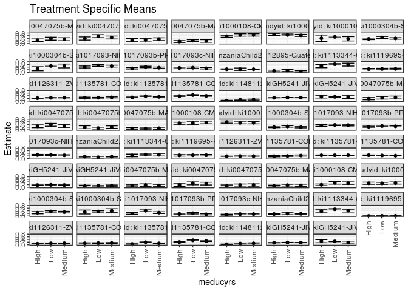

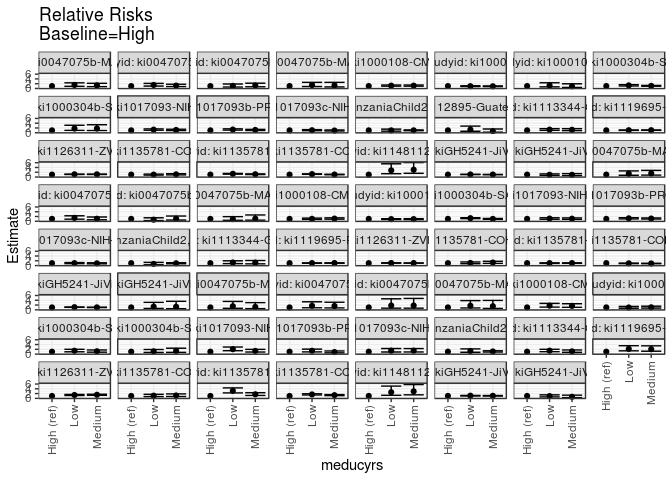

[figure not shown]

[figure not shown]

## Results Table

### Parameter: TSM

| agecat | studyid | country | intervention_level | baseline_level | estimate | ci_lower | ci_upper |
| --- | --- | --- | --- | --- | --- | --- | --- |
| 0-24 months | ki0047075b-MAL-ED | BANGLADESH | High | NA | 0.2557390 | 0.1589064 | 0.3525715 |
| 0-24 months | ki0047075b-MAL-ED | BANGLADESH | Low | NA | 0.3717522 | 0.2603019 | 0.4832025 |
| 0-24 months | ki0047075b-MAL-ED | BANGLADESH | Medium | NA | 0.3320288 | 0.2182413 | 0.4458162 |
| 0-24 months | ki0047075b-MAL-ED | INDIA | High | NA | 0.3848872 | 0.2636622 | 0.5061122 |
| 0-24 months | ki0047075b-MAL-ED | INDIA | Low | NA | 0.5641188 | 0.4512311 | 0.6770065 |
| 0-24 months | ki0047075b-MAL-ED | INDIA | Medium | NA | 0.4600961 | 0.3492030 | 0.5709892 |
| 0-24 months | ki0047075b-MAL-ED | NEPAL | High | NA | 0.2624759 | 0.1412847 | 0.3836671 |
| 0-24 months | ki0047075b-MAL-ED | NEPAL | Low | NA | 0.2806798 | 0.1897439 | 0.3716156 |
| 0-24 months | ki0047075b-MAL-ED | NEPAL | Medium | NA | 0.3316740 | 0.2261912 | 0.4371569 |
| 0-24 months | ki0047075b-MAL-ED | SOUTH AFRICA | High | NA | 0.1542407 | 0.0803647 | 0.2281167 |
| 0-24 months | ki0047075b-MAL-ED | SOUTH AFRICA | Low | NA | 0.2230649 | 0.1532946 | 0.2928351 |
| 0-24 months | ki0047075b-MAL-ED | SOUTH AFRICA | Medium | NA | 0.1984358 | 0.1003614 | 0.2965102 |
| 0-24 months | ki1000108-CMC-V-BCS-2002 | INDIA | High | NA | 0.5583114 | 0.4802429 | 0.6363799 |
| 0-24 months | ki1000108-CMC-V-BCS-2002 | INDIA | Low | NA | 0.6555924 | 0.5639727 | 0.7472120 |
| 0-24 months | ki1000108-CMC-V-BCS-2002 | INDIA | Medium | NA | 0.6586262 | 0.5686996 | 0.7485528 |
| 0-24 months | ki1000108-IRC | INDIA | High | NA | 0.6893036 | 0.6074836 | 0.7711237 |
| 0-24 months | ki1000108-IRC | INDIA | Low | NA | 0.6568632 | 0.5836700 | 0.7300563 |
| 0-24 months | ki1000108-IRC | INDIA | Medium | NA | 0.6254882 | 0.5446343 | 0.7063422 |
| 0-24 months | ki1000109-EE | PAKISTAN | High | NA | 0.4000000 | 0.1517525 | 0.6482475 |
| 0-24 months | ki1000109-EE | PAKISTAN | Low | NA | 0.5075988 | 0.4535051 | 0.5616925 |
| 0-24 months | ki1000109-EE | PAKISTAN | Medium | NA | 0.3636364 | 0.1992922 | 0.5279805 |
| 0-24 months | ki1000304b-SAS-CompFeed | INDIA | High | NA | 0.3593043 | 0.2977896 | 0.4208191 |
| 0-24 months | ki1000304b-SAS-CompFeed | INDIA | Low | NA | 0.4646556 | 0.3881804 | 0.5411307 |
| 0-24 months | ki1000304b-SAS-CompFeed | INDIA | Medium | NA | 0.3911605 | 0.3334439 | 0.4488770 |
| 0-24 months | ki1000304b-SAS-FoodSuppl | INDIA | High | NA | 0.2727396 | 0.1194828 | 0.4259965 |
| 0-24 months | ki1000304b-SAS-FoodSuppl | INDIA | Low | NA | 0.4806480 | 0.4267950 | 0.5345011 |
| 0-24 months | ki1000304b-SAS-FoodSuppl | INDIA | Medium | NA | 0.4833116 | 0.3384113 | 0.6282118 |
| 0-24 months | ki1017093-NIH-Birth | BANGLADESH | High | NA | 0.4051419 | 0.3314250 | 0.4788587 |
| 0-24 months | ki1017093-NIH-Birth | BANGLADESH | Low | NA | 0.5264509 | 0.4610531 | 0.5918487 |
| 0-24 months | ki1017093-NIH-Birth | BANGLADESH | Medium | NA | 0.4689435 | 0.3992254 | 0.5386615 |

[output cut: 159 more lines]

### Parameter: E(Y)

| agecat | studyid | country | intervention_level | baseline_level | estimate | ci_lower | ci_upper |
| --- | --- | --- | --- | --- | --- | --- | --- |
| 0-24 months | ki0047075b-MAL-ED | BANGLADESH | NA | NA | 0.3004695 | 0.2387555 | 0.3621835 |
| 0-24 months | ki0047075b-MAL-ED | INDIA | NA | NA | 0.4727273 | 0.4066048 | 0.5388497 |
| 0-24 months | ki0047075b-MAL-ED | NEPAL | NA | NA | 0.2888889 | 0.2295338 | 0.3482440 |
| 0-24 months | ki0047075b-MAL-ED | SOUTH AFRICA | NA | NA | 0.1955128 | 0.1514355 | 0.2395901 |
| 0-24 months | ki1000108-CMC-V-BCS-2002 | INDIA | NA | NA | 0.6139410 | 0.5644682 | 0.6634139 |
| 0-24 months | ki1000108-IRC | INDIA | NA | NA | 0.6560976 | 0.6100625 | 0.7021326 |
| 0-24 months | ki1000109-EE | PAKISTAN | NA | NA | 0.4907162 | 0.4401862 | 0.5412462 |
| 0-24 months | ki1000304b-SAS-CompFeed | INDIA | NA | NA | 0.4150694 | 0.3581204 | 0.4720184 |
| 0-24 months | ki1000304b-SAS-FoodSuppl | INDIA | NA | NA | 0.4712919 | 0.4233811 | 0.5192026 |
| 0-24 months | ki1017093-NIH-Birth | BANGLADESH | NA | NA | 0.4775641 | 0.4383415 | 0.5167867 |
| 0-24 months | ki1017093b-PROVIDE | BANGLADESH | NA | NA | 0.3514286 | 0.3160364 | 0.3868207 |
| 0-24 months | ki1017093c-NIH-Crypto | BANGLADESH | NA | NA | 0.3311346 | 0.2976093 | 0.3646598 |
| 0-24 months | ki1066203-TanzaniaChild2 | TANZANIA, UNITED REPUBLIC OF | NA | NA | 0.2367980 | 0.2197367 | 0.2538593 |
| 0-24 months | ki1112895-Guatemala BSC | GUATEMALA | NA | NA | 0.1063830 | 0.0703329 | 0.1424331 |
| 0-24 months | ki1113344-GMS-Nepal | NEPAL | NA | NA | 0.5909850 | 0.5515796 | 0.6303903 |
| 0-24 months | ki1119695-PROBIT | BELARUS | NA | NA | 0.2565984 | 0.1993515 | 0.3138454 |
| 0-24 months | ki1126311-ZVITAMBO | ZIMBABWE | NA | NA | 0.2346433 | 0.2276029 | 0.2416837 |
| 0-24 months | ki1135781-COHORTS | GUATEMALA | NA | NA | 0.2564297 | 0.2328823 | 0.2799770 |
| 0-24 months | ki1135781-COHORTS | INDIA | NA | NA | 0.3329911 | 0.3209071 | 0.3450751 |
| 0-24 months | ki1135781-COHORTS | PHILIPPINES | NA | NA | 0.4036125 | 0.3861835 | 0.4210415 |
| 0-24 months | ki1148112-LCNI-5 | MALAWI | NA | NA | 0.0798526 | 0.0612199 | 0.0984853 |
| 0-24 months | kiGH5241-JiVitA-3 | BANGLADESH | NA | NA | 0.2581148 | 0.2516506 | 0.2645791 |
| 0-24 months | kiGH5241-JiVitA-4 | BANGLADESH | NA | NA | 0.3168617 | 0.2936158 | 0.3401077 |
| 0-6 months | ki0047075b-MAL-ED | BANGLADESH | NA | NA | 0.2206573 | 0.1648355 | 0.2764790 |
| 0-6 months | ki0047075b-MAL-ED | INDIA | NA | NA | 0.3136364 | 0.2521871 | 0.3750856 |
| 0-6 months | ki0047075b-MAL-ED | NEPAL | NA | NA | 0.1777778 | 0.1277101 | 0.2278455 |
| 0-6 months | ki0047075b-MAL-ED | SOUTH AFRICA | NA | NA | 0.1025641 | 0.0688457 | 0.1362825 |
| 0-6 months | ki1000108-CMC-V-BCS-2002 | INDIA | NA | NA | 0.5190217 | 0.4679041 | 0.5701394 |
| 0-6 months | ki1000108-IRC | INDIA | NA | NA | 0.5439024 | 0.4956326 | 0.5921723 |
| 0-6 months | ki1000304b-SAS-CompFeed | INDIA | NA | NA | 0.2199336 | 0.1753445 | 0.2645227 |
| 0-6 months | ki1017093-NIH-Birth | BANGLADESH | NA | NA | 0.3569132 | 0.3192325 | 0.3945938 |
| 0-6 months | ki1017093b-PROVIDE | BANGLADESH | NA | NA | 0.2585714 | 0.2261125 | 0.2910304 |
| 0-6 months | ki1017093c-NIH-Crypto | BANGLADESH | NA | NA | 0.2585752 | 0.2273844 | 0.2897660 |
| 0-6 months | ki1066203-TanzaniaChild2 | TANZANIA, UNITED REPUBLIC OF | NA | NA | 0.1395641 | 0.1256566 | 0.1534717 |
| 0-6 months | ki1113344-GMS-Nepal | NEPAL | NA | NA | 0.2954925 | 0.2589234 | 0.3320615 |
| 0-6 months | ki1119695-PROBIT | BELARUS | NA | NA | 0.2497780 | 0.1917926 | 0.3077635 |
| 0-6 months | ki1126311-ZVITAMBO | ZIMBABWE | NA | NA | 0.1809503 | 0.1745333 | 0.1873674 |
| 0-6 months | ki1135781-COHORTS | GUATEMALA | NA | NA | 0.2007612 | 0.1765324 | 0.2249900 |
| 0-6 months | ki1135781-COHORTS | INDIA | NA | NA | 0.2511554 | 0.2398221 | 0.2624886 |
| 0-6 months | ki1135781-COHORTS | PHILIPPINES | NA | NA | 0.2355453 | 0.2204685 | 0.2506222 |
| 0-6 months | kiGH5241-JiVitA-3 | BANGLADESH | NA | NA | 0.1763390 | 0.1707116 | 0.1819665 |
| 0-6 months | kiGH5241-JiVitA-4 | BANGLADESH | NA | NA | 0.1126043 | 0.0962730 | 0.1289355 |
| 6-24 months | ki0047075b-MAL-ED | BANGLADESH | NA | NA | 0.1384615 | 0.0898601 | 0.1870630 |
| 6-24 months | ki0047075b-MAL-ED | INDIA | NA | NA | 0.2657005 | 0.2053824 | 0.3260185 |
| 6-24 months | ki0047075b-MAL-ED | NEPAL | NA | NA | 0.1545455 | 0.1066715 | 0.2024194 |
| 6-24 months | ki0047075b-MAL-ED | SOUTH AFRICA | NA | NA | 0.1389961 | 0.0967835 | 0.1812087 |
| 6-24 months | ki1000108-CMC-V-BCS-2002 | INDIA | NA | NA | 0.2654155 | 0.2205451 | 0.3102860 |
| 6-24 months | ki1000108-IRC | INDIA | NA | NA | 0.3097561 | 0.2649438 | 0.3545684 |
| 6-24 months | ki1000304b-SAS-CompFeed | INDIA | NA | NA | 0.3059755 | 0.2638053 | 0.3481458 |
| 6-24 months | ki1000304b-SAS-FoodSuppl | INDIA | NA | NA | 0.3557214 | 0.3088651 | 0.4025777 |
| 6-24 months | ki1017093-NIH-Birth | BANGLADESH | NA | NA | 0.2939002 | 0.2554778 | 0.3323226 |
| 6-24 months | ki1017093b-PROVIDE | BANGLADESH | NA | NA | 0.1609756 | 0.1319065 | 0.1900447 |
| 6-24 months | ki1017093c-NIH-Crypto | BANGLADESH | NA | NA | 0.1315069 | 0.1069744 | 0.1560393 |
| 6-24 months | ki1066203-TanzaniaChild2 | TANZANIA, UNITED REPUBLIC OF | NA | NA | 0.1606166 | 0.1445647 | 0.1766685 |
| 6-24 months | ki1113344-GMS-Nepal | NEPAL | NA | NA | 0.4735945 | 0.4331684 | 0.5140207 |
| 6-24 months | ki1119695-PROBIT | BELARUS | NA | NA | 0.0100615 | 0.0072668 | 0.0128561 |
| 6-24 months | ki1126311-ZVITAMBO | ZIMBABWE | NA | NA | 0.0940163 | 0.0884807 | 0.0995519 |
| 6-24 months | ki1135781-COHORTS | GUATEMALA | NA | NA | 0.1277129 | 0.1088047 | 0.1466210 |
| 6-24 months | ki1135781-COHORTS | INDIA | NA | NA | 0.1266654 | 0.1178579 | 0.1354730 |
| 6-24 months | ki1135781-COHORTS | PHILIPPINES | NA | NA | 0.2666429 | 0.2502871 | 0.2829988 |
| 6-24 months | ki1148112-LCNI-5 | MALAWI | NA | NA | 0.0772105 | 0.0587369 | 0.0956840 |
| 6-24 months | kiGH5241-JiVitA-3 | BANGLADESH | NA | NA | 0.1638889 | 0.1577625 | 0.1700152 |
| 6-24 months | kiGH5241-JiVitA-4 | BANGLADESH | NA | NA | 0.2529335 | 0.2320005 | 0.2738666 |

### Parameter: RR

| agecat | studyid | country | intervention_level | baseline_level | estimate | ci_lower | ci_upper |
| --- | --- | --- | --- | --- | --- | --- | --- |
| 0-24 months | ki0047075b-MAL-ED | BANGLADESH | High | High | 1.0000000 | 1.0000000 | 1.0000000 |
| 0-24 months | ki0047075b-MAL-ED | BANGLADESH | Low | High | 1.4536395 | 0.8977794 | 2.3536604 |
| 0-24 months | ki0047075b-MAL-ED | BANGLADESH | Medium | High | 1.2983113 | 0.7779879 | 2.1666304 |
| 0-24 months | ki0047075b-MAL-ED | INDIA | High | High | 1.0000000 | 1.0000000 | 1.0000000 |
| 0-24 months | ki0047075b-MAL-ED | INDIA | Low | High | 1.4656731 | 1.0093375 | 2.1283245 |
| 0-24 months | ki0047075b-MAL-ED | INDIA | Medium | High | 1.1954051 | 0.8027073 | 1.7802174 |
| 0-24 months | ki0047075b-MAL-ED | NEPAL | High | High | 1.0000000 | 1.0000000 | 1.0000000 |
| 0-24 months | ki0047075b-MAL-ED | NEPAL | Low | High | 1.0693545 | 0.6092977 | 1.8767821 |
| 0-24 months | ki0047075b-MAL-ED | NEPAL | Medium | High | 1.2636362 | 0.7236352 | 2.2066044 |
| 0-24 months | ki0047075b-MAL-ED | SOUTH AFRICA | High | High | 1.0000000 | 1.0000000 | 1.0000000 |
| 0-24 months | ki0047075b-MAL-ED | SOUTH AFRICA | Low | High | 1.4462130 | 0.8153254 | 2.5652727 |
| 0-24 months | ki0047075b-MAL-ED | SOUTH AFRICA | Medium | High | 1.2865337 | 0.6462845 | 2.5610531 |
| 0-24 months | ki1000108-CMC-V-BCS-2002 | INDIA | High | High | 1.0000000 | 1.0000000 | 1.0000000 |
| 0-24 months | ki1000108-CMC-V-BCS-2002 | INDIA | Low | High | 1.1742415 | 0.9634084 | 1.4312135 |
| 0-24 months | ki1000108-CMC-V-BCS-2002 | INDIA | Medium | High | 1.1796754 | 0.9703566 | 1.4341469 |
| 0-24 months | ki1000108-IRC | INDIA | High | High | 1.0000000 | 1.0000000 | 1.0000000 |
| 0-24 months | ki1000108-IRC | INDIA | Low | High | 0.9529373 | 0.8133744 | 1.1164471 |
| 0-24 months | ki1000108-IRC | INDIA | Medium | High | 0.9074205 | 0.7624181 | 1.0800006 |
| 0-24 months | ki1000109-EE | PAKISTAN | High | High | 1.0000000 | 1.0000000 | 1.0000000 |
| 0-24 months | ki1000109-EE | PAKISTAN | Low | High | 1.2689970 | 0.6760590 | 2.3819715 |
| 0-24 months | ki1000109-EE | PAKISTAN | Medium | High | 0.9090909 | 0.4218738 | 1.9589894 |
| 0-24 months | ki1000304b-SAS-CompFeed | INDIA | High | High | 1.0000000 | 1.0000000 | 1.0000000 |
| 0-24 months | ki1000304b-SAS-CompFeed | INDIA | Low | High | 1.2932089 | 1.0499833 | 1.5927771 |
| 0-24 months | ki1000304b-SAS-CompFeed | INDIA | Medium | High | 1.0886606 | 0.9343653 | 1.2684353 |
| 0-24 months | ki1000304b-SAS-FoodSuppl | INDIA | High | High | 1.0000000 | 1.0000000 | 1.0000000 |
| 0-24 months | ki1000304b-SAS-FoodSuppl | INDIA | Low | High | 1.7622964 | 0.9930875 | 3.1273062 |
| 0-24 months | ki1000304b-SAS-FoodSuppl | INDIA | Medium | High | 1.7720623 | 0.9368702 | 3.3518034 |
| 0-24 months | ki1017093-NIH-Birth | BANGLADESH | High | High | 1.0000000 | 1.0000000 | 1.0000000 |
| 0-24 months | ki1017093-NIH-Birth | BANGLADESH | Low | High | 1.2994236 | 1.0444650 | 1.6166188 |
| 0-24 months | ki1017093-NIH-Birth | BANGLADESH | Medium | High | 1.1574797 | 0.9158776 | 1.4628148 |

[output cut: 159 more lines]

### Parameter: PAR

| agecat | studyid | country | intervention_level | baseline_level | estimate | ci_lower | ci_upper |
| --- | --- | --- | --- | --- | --- | --- | --- |
| 0-24 months | ki0047075b-MAL-ED | BANGLADESH | High | NA | 0.0447305 | -0.0357767 | 0.1252377 |
| 0-24 months | ki0047075b-MAL-ED | INDIA | High | NA | 0.0878401 | -0.0160579 | 0.1917380 |
| 0-24 months | ki0047075b-MAL-ED | NEPAL | High | NA | 0.0264130 | -0.0807575 | 0.1335835 |
| 0-24 months | ki0047075b-MAL-ED | SOUTH AFRICA | High | NA | 0.0412722 | -0.0231624 | 0.1057067 |
| 0-24 months | ki1000108-CMC-V-BCS-2002 | INDIA | High | NA | 0.0556296 | -0.0032541 | 0.1145134 |
| 0-24 months | ki1000108-IRC | INDIA | High | NA | -0.0332061 | -0.1009131 | 0.0345010 |
| 0-24 months | ki1000109-EE | PAKISTAN | High | NA | 0.0907162 | -0.1527507 | 0.3341830 |
| 0-24 months | ki1000304b-SAS-CompFeed | INDIA | High | NA | 0.0557651 | -0.0006686 | 0.1121987 |
| 0-24 months | ki1000304b-SAS-FoodSuppl | INDIA | High | NA | 0.1985522 | 0.0513684 | 0.3457361 |
| 0-24 months | ki1017093-NIH-Birth | BANGLADESH | High | NA | 0.0724222 | 0.0089495 | 0.1358950 |
| 0-24 months | ki1017093b-PROVIDE | BANGLADESH | High | NA | 0.0478351 | 0.0107631 | 0.0849070 |
| 0-24 months | ki1017093c-NIH-Crypto | BANGLADESH | High | NA | -0.0038305 | -0.0445932 | 0.0369322 |
| 0-24 months | ki1066203-TanzaniaChild2 | TANZANIA, UNITED REPUBLIC OF | High | NA | 0.0003908 | -0.0285112 | 0.0292928 |
| 0-24 months | ki1112895-Guatemala BSC | GUATEMALA | High | NA | -0.0037865 | -0.0464720 | 0.0388989 |
| 0-24 months | ki1113344-GMS-Nepal | NEPAL | High | NA | 0.1192851 | 0.0023545 | 0.2362158 |
| 0-24 months | ki1119695-PROBIT | BELARUS | High | NA | 0.0133636 | 0.0002783 | 0.0264489 |
| 0-24 months | ki1126311-ZVITAMBO | ZIMBABWE | High | NA | 0.0141999 | 0.0091555 | 0.0192442 |
| 0-24 months | ki1135781-COHORTS | GUATEMALA | High | NA | 0.0032939 | -0.0368429 | 0.0434307 |
| 0-24 months | ki1135781-COHORTS | INDIA | High | NA | 0.0563201 | 0.0298777 | 0.0827624 |
| 0-24 months | ki1135781-COHORTS | PHILIPPINES | High | NA | 0.0268168 | 0.0069869 | 0.0466468 |
| 0-24 months | ki1148112-LCNI-5 | MALAWI | High | NA | 0.0435749 | 0.0219875 | 0.0651623 |
| 0-24 months | kiGH5241-JiVitA-3 | BANGLADESH | High | NA | 0.0094469 | 0.0015482 | 0.0173456 |
| 0-24 months | kiGH5241-JiVitA-4 | BANGLADESH | High | NA | -0.0177591 | -0.1199494 | 0.0844311 |
| 0-6 months | ki0047075b-MAL-ED | BANGLADESH | High | NA | 0.0396390 | -0.0319264 | 0.1112044 |
| 0-6 months | ki0047075b-MAL-ED | INDIA | High | NA | 0.0474694 | -0.0430947 | 0.1380336 |
| 0-6 months | ki0047075b-MAL-ED | NEPAL | High | NA | -0.0152209 | -0.1099475 | 0.0795057 |
| 0-6 months | ki0047075b-MAL-ED | SOUTH AFRICA | High | NA | -0.0026991 | -0.0539914 | 0.0485933 |
| 0-6 months | ki1000108-CMC-V-BCS-2002 | INDIA | High | NA | 0.0263174 | -0.0337441 | 0.0863789 |
| 0-6 months | ki1000108-IRC | INDIA | High | NA | -0.0427931 | -0.1112499 | 0.0256636 |
| 0-6 months | ki1000304b-SAS-CompFeed | INDIA | High | NA | 0.0249812 | -0.0027199 | 0.0526823 |
| 0-6 months | ki1017093-NIH-Birth | BANGLADESH | High | NA | 0.0307824 | -0.0263049 | 0.0878698 |
| 0-6 months | ki1017093b-PROVIDE | BANGLADESH | High | NA | 0.0264890 | -0.0024469 | 0.0554250 |
| 0-6 months | ki1017093c-NIH-Crypto | BANGLADESH | High | NA | -0.0084257 | -0.0425845 | 0.0257330 |
| 0-6 months | ki1066203-TanzaniaChild2 | TANZANIA, UNITED REPUBLIC OF | High | NA | -0.0069737 | -0.0307331 | 0.0167856 |
| 0-6 months | ki1113344-GMS-Nepal | NEPAL | High | NA | 0.0616183 | -0.0324227 | 0.1556593 |
| 0-6 months | ki1119695-PROBIT | BELARUS | High | NA | 0.0086241 | -0.0044807 | 0.0217289 |
| 0-6 months | ki1126311-ZVITAMBO | ZIMBABWE | High | NA | 0.0044395 | 0.0011206 | 0.0077583 |
| 0-6 months | ki1135781-COHORTS | GUATEMALA | High | NA | 0.0226228 | -0.0217956 | 0.0670412 |
| 0-6 months | ki1135781-COHORTS | INDIA | High | NA | 0.0061624 | -0.0168877 | 0.0292125 |
| 0-6 months | ki1135781-COHORTS | PHILIPPINES | High | NA | -0.0164917 | -0.0307612 | -0.0022223 |
| 0-6 months | kiGH5241-JiVitA-3 | BANGLADESH | High | NA | 0.0090470 | 0.0032105 | 0.0148835 |
| 0-6 months | kiGH5241-JiVitA-4 | BANGLADESH | High | NA | 0.0268900 | -0.0449126 | 0.0986925 |
| 6-24 months | ki0047075b-MAL-ED | BANGLADESH | High | NA | 0.0257855 | -0.0361817 | 0.0877527 |
| 6-24 months | ki0047075b-MAL-ED | INDIA | High | NA | 0.0925764 | 0.0024324 | 0.1827204 |
| 6-24 months | ki0047075b-MAL-ED | NEPAL | High | NA | 0.0583916 | -0.0170578 | 0.1338410 |
| 6-24 months | ki0047075b-MAL-ED | SOUTH AFRICA | High | NA | 0.0444015 | -0.0163828 | 0.1051859 |
| 6-24 months | ki1000108-CMC-V-BCS-2002 | INDIA | High | NA | 0.0761009 | 0.0244818 | 0.1277200 |
| 6-24 months | ki1000108-IRC | INDIA | High | NA | 0.0054078 | -0.0630578 | 0.0738734 |
| 6-24 months | ki1000304b-SAS-CompFeed | INDIA | High | NA | 0.0565575 | -0.0186116 | 0.1317267 |
| 6-24 months | ki1000304b-SAS-FoodSuppl | INDIA | High | NA | 0.0533223 | -0.0888630 | 0.1955076 |
| 6-24 months | ki1017093-NIH-Birth | BANGLADESH | High | NA | 0.0996526 | 0.0431999 | 0.1561053 |
| 6-24 months | ki1017093b-PROVIDE | BANGLADESH | High | NA | 0.0066943 | -0.0317284 | 0.0451170 |
| 6-24 months | ki1017093c-NIH-Crypto | BANGLADESH | High | NA | 0.0306168 | -0.0018330 | 0.0630666 |
| 6-24 months | ki1066203-TanzaniaChild2 | TANZANIA, UNITED REPUBLIC OF | High | NA | 0.0118964 | -0.0150405 | 0.0388333 |
| 6-24 months | ki1113344-GMS-Nepal | NEPAL | High | NA | 0.1149043 | 0.0028599 | 0.2269487 |
| 6-24 months | ki1119695-PROBIT | BELARUS | High | NA | 0.0048124 | 0.0020481 | 0.0075767 |
| 6-24 months | ki1126311-ZVITAMBO | ZIMBABWE | High | NA | 0.0158306 | 0.0102463 | 0.0214149 |
| 6-24 months | ki1135781-COHORTS | GUATEMALA | High | NA | 0.0168881 | -0.0189728 | 0.0527490 |
| 6-24 months | ki1135781-COHORTS | INDIA | High | NA | 0.0654241 | 0.0464068 | 0.0844414 |
| 6-24 months | ki1135781-COHORTS | PHILIPPINES | High | NA | 0.0611762 | 0.0403559 | 0.0819965 |
| 6-24 months | ki1148112-LCNI-5 | MALAWI | High | NA | 0.0404193 | 0.0189273 | 0.0619114 |
| 6-24 months | kiGH5241-JiVitA-3 | BANGLADESH | High | NA | 0.0087855 | -0.0009975 | 0.0185685 |
| 6-24 months | kiGH5241-JiVitA-4 | BANGLADESH | High | NA | -0.0168693 | -0.1315822 | 0.0978436 |

### Parameter: PAF

| agecat | studyid | country | intervention_level | baseline_level | estimate | ci_lower | ci_upper |
| --- | --- | --- | --- | --- | --- | --- | --- |
| 0-24 months | ki0047075b-MAL-ED | BANGLADESH | High | NA | 0.1488688 | -0.1645771 | 0.3779508 |
| 0-24 months | ki0047075b-MAL-ED | INDIA | High | NA | 0.1858156 | -0.0673367 | 0.3789249 |
| 0-24 months | ki0047075b-MAL-ED | NEPAL | High | NA | 0.0914296 | -0.3667350 | 0.3960057 |
| 0-24 months | ki0047075b-MAL-ED | SOUTH AFRICA | High | NA | 0.2110969 | -0.1950950 | 0.4792313 |
| 0-24 months | ki1000108-CMC-V-BCS-2002 | INDIA | High | NA | 0.0906107 | -0.0110987 | 0.1820889 |
| 0-24 months | ki1000108-IRC | INDIA | High | NA | -0.0506115 | -0.1591195 | 0.0477388 |
| 0-24 months | ki1000109-EE | PAKISTAN | High | NA | 0.1848649 | -0.4985851 | 0.5566182 |
| 0-24 months | ki1000304b-SAS-CompFeed | INDIA | High | NA | 0.1343512 | -0.0053075 | 0.2546083 |
| 0-24 months | ki1000304b-SAS-FoodSuppl | INDIA | High | NA | 0.4212936 | 0.0047017 | 0.6635169 |
| 0-24 months | ki1017093-NIH-Birth | BANGLADESH | High | NA | 0.1516493 | 0.0074697 | 0.2748846 |
| 0-24 months | ki1017093b-PROVIDE | BANGLADESH | High | NA | 0.1361161 | 0.0239005 | 0.2354309 |
| 0-24 months | ki1017093c-NIH-Crypto | BANGLADESH | High | NA | -0.0115679 | -0.1424469 | 0.1043176 |
| 0-24 months | ki1066203-TanzaniaChild2 | TANZANIA, UNITED REPUBLIC OF | High | NA | 0.0016503 | -0.1281778 | 0.1165381 |
| 0-24 months | ki1112895-Guatemala BSC | GUATEMALA | High | NA | -0.0355932 | -0.5254587 | 0.2969634 |
| 0-24 months | ki1113344-GMS-Nepal | NEPAL | High | NA | 0.2018413 | -0.0229756 | 0.3772506 |
| 0-24 months | ki1119695-PROBIT | BELARUS | High | NA | 0.0520799 | -0.0021903 | 0.1034112 |
| 0-24 months | ki1126311-ZVITAMBO | ZIMBABWE | High | NA | 0.0605168 | 0.0388365 | 0.0817081 |
| 0-24 months | ki1135781-COHORTS | GUATEMALA | High | NA | 0.0128451 | -0.1567536 | 0.1575779 |
| 0-24 months | ki1135781-COHORTS | INDIA | High | NA | 0.1691338 | 0.0859736 | 0.2447280 |
| 0-24 months | ki1135781-COHORTS | PHILIPPINES | High | NA | 0.0664420 | 0.0160541 | 0.1142496 |
| 0-24 months | ki1148112-LCNI-5 | MALAWI | High | NA | 0.5456915 | 0.2267657 | 0.7330741 |
| 0-24 months | kiGH5241-JiVitA-3 | BANGLADESH | High | NA | 0.0365995 | 0.0055417 | 0.0666874 |
| 0-24 months | kiGH5241-JiVitA-4 | BANGLADESH | High | NA | -0.0560469 | -0.4336178 | 0.2220834 |
| 0-6 months | ki0047075b-MAL-ED | BANGLADESH | High | NA | 0.1796407 | -0.2148126 | 0.4460138 |
| 0-6 months | ki0047075b-MAL-ED | INDIA | High | NA | 0.1513518 | -0.1917472 | 0.3956740 |
| 0-6 months | ki0047075b-MAL-ED | NEPAL | High | NA | -0.0856177 | -0.7719432 | 0.3348738 |
| 0-6 months | ki0047075b-MAL-ED | SOUTH AFRICA | High | NA | -0.0263158 | -0.6706242 | 0.3695027 |
| 0-6 months | ki1000108-CMC-V-BCS-2002 | INDIA | High | NA | 0.0507058 | -0.0724581 | 0.1597252 |
| 0-6 months | ki1000108-IRC | INDIA | High | NA | -0.0786780 | -0.2124446 | 0.0403304 |
| 0-6 months | ki1000304b-SAS-CompFeed | INDIA | High | NA | 0.1135853 | -0.0075799 | 0.2201800 |
| 0-6 months | ki1017093-NIH-Birth | BANGLADESH | High | NA | 0.0862463 | -0.0886458 | 0.2330417 |
| 0-6 months | ki1017093b-PROVIDE | BANGLADESH | High | NA | 0.1024438 | -0.0170921 | 0.2079310 |
| 0-6 months | ki1017093c-NIH-Crypto | BANGLADESH | High | NA | -0.0325851 | -0.1732604 | 0.0912230 |
| 0-6 months | ki1066203-TanzaniaChild2 | TANZANIA, UNITED REPUBLIC OF | High | NA | -0.0499678 | -0.2347294 | 0.1071465 |
| 0-6 months | ki1113344-GMS-Nepal | NEPAL | High | NA | 0.2085276 | -0.1815626 | 0.4698304 |
| 0-6 months | ki1119695-PROBIT | BELARUS | High | NA | 0.0345271 | -0.0201588 | 0.0862815 |
| 0-6 months | ki1126311-ZVITAMBO | ZIMBABWE | High | NA | 0.0245341 | 0.0060430 | 0.0426812 |
| 0-6 months | ki1135781-COHORTS | GUATEMALA | High | NA | 0.1126851 | -0.1378255 | 0.3080417 |
| 0-6 months | ki1135781-COHORTS | INDIA | High | NA | 0.0245362 | -0.0716785 | 0.1121128 |
| 0-6 months | ki1135781-COHORTS | PHILIPPINES | High | NA | -0.0700151 | -0.1323252 | -0.0111337 |
| 0-6 months | kiGH5241-JiVitA-3 | BANGLADESH | High | NA | 0.0513047 | 0.0175616 | 0.0838888 |
| 0-6 months | kiGH5241-JiVitA-4 | BANGLADESH | High | NA | 0.2388005 | -0.7544489 | 0.6697398 |
| 6-24 months | ki0047075b-MAL-ED | BANGLADESH | High | NA | 0.1862285 | -0.4042934 | 0.5284290 |
| 6-24 months | ki0047075b-MAL-ED | INDIA | High | NA | 0.3484240 | -0.0897506 | 0.6104142 |
| 6-24 months | ki0047075b-MAL-ED | NEPAL | High | NA | 0.3778280 | -0.3397954 | 0.7110768 |
| 6-24 months | ki0047075b-MAL-ED | SOUTH AFRICA | High | NA | 0.3194444 | -0.2779704 | 0.6375848 |
| 6-24 months | ki1000108-CMC-V-BCS-2002 | INDIA | High | NA | 0.2867235 | 0.0673871 | 0.4544753 |
| 6-24 months | ki1000108-IRC | INDIA | High | NA | 0.0174583 | -0.2304221 | 0.2154009 |
| 6-24 months | ki1000304b-SAS-CompFeed | INDIA | High | NA | 0.1848433 | -0.1023276 | 0.3972024 |
| 6-24 months | ki1000304b-SAS-FoodSuppl | INDIA | High | NA | 0.1498991 | -0.3607823 | 0.4689293 |
| 6-24 months | ki1017093-NIH-Birth | BANGLADESH | High | NA | 0.3390695 | 0.1199766 | 0.5036165 |
| 6-24 months | ki1017093b-PROVIDE | BANGLADESH | High | NA | 0.0415857 | -0.2288267 | 0.2524919 |
| 6-24 months | ki1017093c-NIH-Crypto | BANGLADESH | High | NA | 0.2328155 | -0.0532804 | 0.4412009 |
| 6-24 months | ki1066203-TanzaniaChild2 | TANZANIA, UNITED REPUBLIC OF | High | NA | 0.0740670 | -0.1096622 | 0.2273757 |
| 6-24 months | ki1113344-GMS-Nepal | NEPAL | High | NA | 0.2426216 | -0.0349683 | 0.4457589 |
| 6-24 months | ki1119695-PROBIT | BELARUS | High | NA | 0.4783011 | 0.1993641 | 0.6600581 |
| 6-24 months | ki1126311-ZVITAMBO | ZIMBABWE | High | NA | 0.1683818 | 0.1076877 | 0.2249475 |
| 6-24 months | ki1135781-COHORTS | GUATEMALA | High | NA | 0.1322348 | -0.1986966 | 0.3718040 |
| 6-24 months | ki1135781-COHORTS | INDIA | High | NA | 0.5165112 | 0.3469116 | 0.6420677 |
| 6-24 months | ki1135781-COHORTS | PHILIPPINES | High | NA | 0.2294310 | 0.1480885 | 0.3030068 |
| 6-24 months | ki1148112-LCNI-5 | MALAWI | High | NA | 0.5234952 | 0.1926726 | 0.7187550 |
| 6-24 months | kiGH5241-JiVitA-3 | BANGLADESH | High | NA | 0.0536065 | -0.0079409 | 0.1113957 |
| 6-24 months | kiGH5241-JiVitA-4 | BANGLADESH | High | NA | -0.0666947 | -0.6323704 | 0.3029537 |